# World Cup Packages Final Analysis

Kyle Arbide, Ava Gholipour, Prathyaj Mantha, Vibhav Lekhi

December 11, 2022

# Abstract

To understand the soccer fans and their preferences, we analyzed alternative products to provide soccer fans willing to travel to the 2022 FIFA World Cup in Qatar by suggesting 3 levels of Pass Quality, options for seat location in the stadium and prices ranging from $500 per ticket to $3500 per ticket. The options contained different seating,level,cost and pass quality.

In this report,we analyze the factors that soccer fans prioritized during their consideration of buying tickets to the Qatar 2022 world cup. We look at the motivational factor and their priorities behind the decisions of the fans in our survey.

# Introduction

The 2022 FIFA World Cup in Qatar is expecting 1.2 million visitors during the November to December period and is set to generate profits close to $17 billion. 32 teams will participate in a round-robin-knockout style tournament over the course of 8 weeks. Games will be played almost every day across 5 cities, with 8 stadiums hosting the matches. With groups of 4, each team playing the other teams within their group,the winner and runner up of every group will advance to the knockout stage of the tournament. The knockout stage will be an elimination-style playoff. With the showpiece final being held on 18 December 2022.

64 games are expected to be played to decide the world cup, with 32 nations competing. Over 1.4 million fans are expected to be traveling to the world cup. The final is expected to host 80,000 fans at the stadium, and over one and a half billion viewers are expected to tune in for the flagship event. The travel and hospitality industry is expected to make record revenues post-pandemic. In preparation, several airlines and travel companies are offering a range of World Cup Packages that include travel, stay, and tickets to the games. We will be offering combinations that include three tiers, i.e., Bronze, Silver, and Gold.

- Bronze: This pass only allows you access to Group Stage games
- Silver: This pass allows you to access Group Stage, Round of 16, or Quarter Finals games
- Gold: This pass allows you to access games from any stage (Group Stage, Round of 16, Quarter Finals, Semi Finals, and Finals)

Customers will be offered a range of seat locations in the stadiums as described in the following diagram:

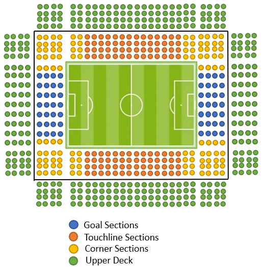

# Survey Design

We start by asking survey takers if they are soccer/football fans. This is to gauge whether the World Cup is a relevant event for the customer. We follow that with a question about their willingness to travel to attend a sporting event. If the answer to either question is ‘No’, then the survey taker is not a relevant consumer of the product.

Following the screening questions, the respondents are presented with an introduction to the product. They are given knowledge about the Pass Quality (Bronze, Silver and Gold), how many games are included in each pass, and Seat Quality (as described in the image above- Goal Sections, Touchline Sections, Corner Sections and Upper Sections).

Following the knowledge section of the survey, the survey taker is presented with a series of eight questions with 3 options in each. The attributes chosen to differentiate between each option presented are Price, Seat Location, Number of Games and Pass Quality.

We chose price to analyze how a company offering such a product could maximize profits while providing prices that consumers deem reasonable. Seat location is often viewed as critical for fans across sports as a key decision variable between attending games or streaming it from home. Number of Games and Pass Quality help us determine how much a consumer values watching their favorite team progress through groups and move on to the knockout stages or would they rather watch games in the later stages of the tournament such as the late knockouts and final. Throughout the survey conjoint questions we have also included information about pass quality and seat quality to help survey takers.

For the demographic questions we included a question about the age range of the respondents, their yearly household income and how much they would be willing to spend on the event. We also asked them which team they would be supporting during the tournament as well as which other teams, if any, they would be interested in watching.

# Data Analysis

## Sample Description and Data Cleaning

Our final sample contained a total of 295 respondents initially, following filtering based on completion of survey and the screen out question, we had **168 respondents** remaining for analysis. We filtered out responses that were screened out due to incorrect answers in the screen out question and incomplete survey responses.

## Modeling and Results

Our utility model for ticket packages is as follows:

$$\upsilon_{j} = \beta
_{1}x_{j}^{price}+\beta _{2}x_{j}^{num games}+\beta _{3}\delta
_{j}^{silver}+\beta _{4}\delta _{j}^{gold}+\beta _{5}\delta
_{j}^{corner}+\beta _{6}\delta _{j}^{touchline}+\beta _{7}\delta
_{j}^{goal} + \epsilon_{j}$$

‘silver’ and ‘gold’ are our dummy variables for pass quality and ‘corner’, ‘touchline’, and ‘goal’ are the dummy variables for seat quality. With the sample responses from above, we were able to estimate the coefficients for our attributes using logistic regression.

The results of this model were as follows:

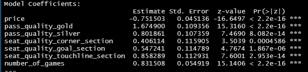

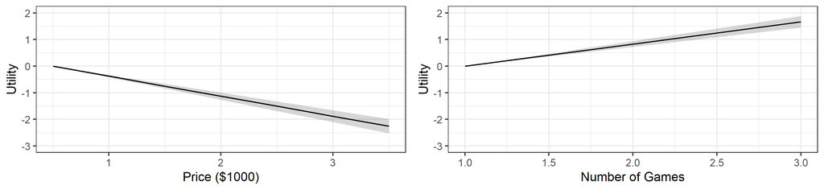

The price attribute is in line with what we determined in our pilot analysis, i.e., utility decreases with increase in Price. This is expected from respondents as a cheaper option is commonly preferred. We also observe that utility is directly proportional to number of games.

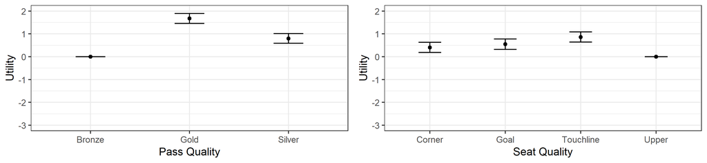

From our dummy columns, we gathered that the highest utility is observed for a Gold pass as expected, since it gives access to the latter stages of the tournament. However, for seat quality, not too much variation is observed with touchline and goal sections being the most preferred while the upper section was the least preferred seat selection.

### Mixed Logit

Using a mixed logit model gave us the following results.

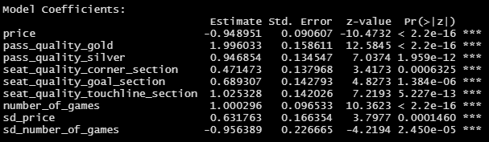

Here, the results do not differ from our Simple logit model, however the Standard error terms are significant and therefore we ran a grouped logit model to obtain the following results.

### Grouped Model

From the result above, we observed that there might be different groups of respondents with different observed utility for number of games. We weren’y sure which groups might have caused this, so we chose to investigate the difference between those respondent whose favorite team is USA vs others. We capture these demographics as part of our initial survey, so making this differentiation was simple. By including the interaction term of number of games times USA fan, we were able to estimate the following model.

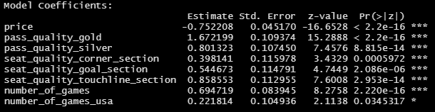

We plotted our results with a 95% confidence interval and observed the following deviations from our simple logit model.

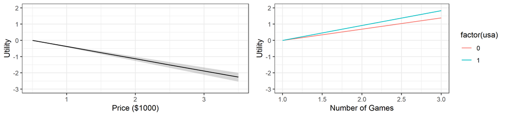

While the price variable does not exhibit deviation from previous observations, when a respondent is supporting the USMNT, it is clear that they experience a higher utility when they get to attend more games compared to other respondents.

## Willingness To Pay

We estimated the willingness to pay for each attribute in our analysis and based on respondents’ surveys we found the following results. We estimated a willingness to pay space by using the logitr function in R and scaling all attributes by price. We used a multistart since the log-likelihood is a non convex function.

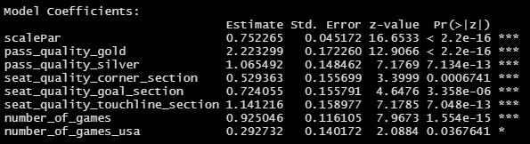

On plotting the above results, we obtained the following plot for the WTP Space for each attribute.

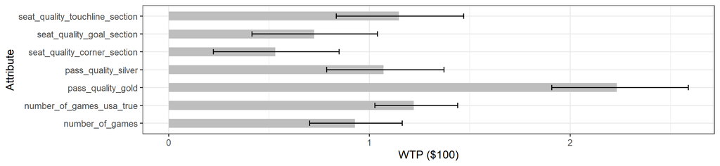

#### Seat Quality

Customers tend to prefer the Touchline section the most. The Upper Deck is the least preferred section as the willingness to pay for all other sections is positive.

#### Pass Quality

The Bronze pass is used as a baseline and as the Silver and Gold passes have a positive willingness to pay, the Bronze pass has the least preference in this case. Based on our analysis, the Gold pass has the highest willingness to pay.

#### Number of games

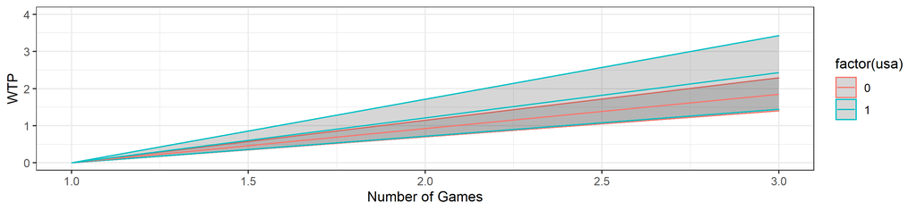

Fans who support the USA in the tournament have a different preference to the other fans. The WTP of the USA increases with respect to the number of games. With a WTP factor of 2.5 for 3 games. The WTP of the non-USA fans tends to increase with the number of games but only by a factor of 1.8. There is a different WTP for the number of games between the USA fans and the Non-USA fans. The lower bound of the USA and non-USA fans are in line, with the mean of the USA fans higher than the upper limit of non-USA Fans. A higher number of games is obviously preferred, however, USA fans appear to have a higher willingness to pay for more games.

## Market Share

For our competition scenario, we came up with three competing alternatives for different ticketing packages. The alternatives were as follows: This is a Gold pass (includes the final), but only 1 game is included This is a Silver pass (includes early knockouts, but not final), and 2 games are included This is a Bronze pass (includes only group stage), and 3 games are included The idea behind these alternatives was to understand how important going to the final would be compared to getting to go to a higher volume of less important games. For these three scenarios, all other attributes were held constant (Price and Seat Quality). We also held our groups constant, which means that in all these scenarios the customer is a non-USA fan. We used the predict function in R to calculate market share for each of these cases and got the following result.

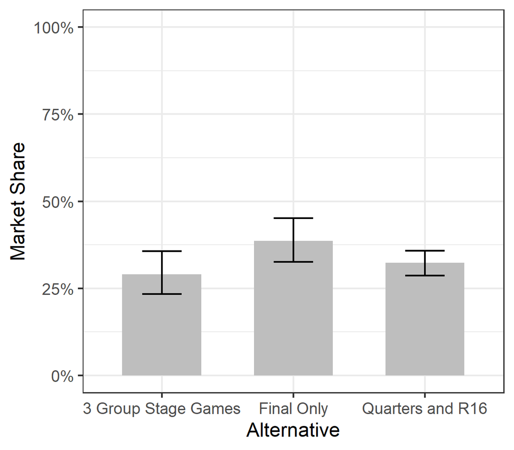

As we can see, each of the alternatives offers very similar market share, with the final being preferred slightly. However, looking at the confidence intervals, since they are each overlapping we cannot make a definitive conclusion as to the preferred alternative.

## Sensitivity Analysis

We were interested in understanding what incentives the customers were interested in to persuade them to choose group stage games over the early knockout stage and late knockout stage games. For this we conducted our sensitivity analysis using the predict function in R. We started by seeing how many games would need to be offered to encourage the Bronze package over the alternatives.

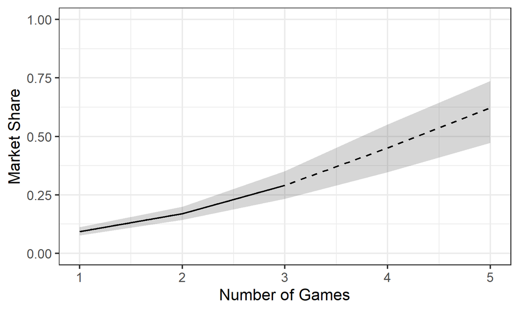

Our sensitivity analysis shows that in order to generate 50% market share for the Bronze pass option, we would need to offer tickets to 5 different games. We continued this sensitivity analysis by varying additional attributes, including seat quality and price, to see what different kinds of offers we could create.

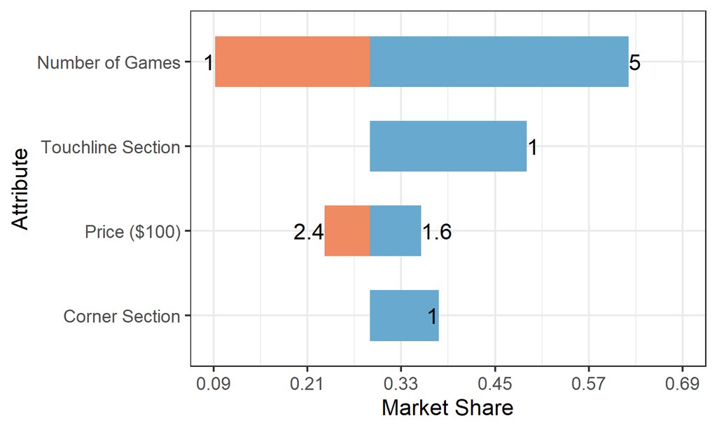

In our analysis we observed the strong preference of the fans of the touchline section over any other sections. Including the touchline section seats instead of the default upper deck seat would achieve almost 50% market share for the Bronze option. The corner section also provides an improvement, bringing the market share up marginally to around 40%. Finally, we can see the effect of the price being raised or lowered by 20%. Raising the price would bring down the market share by around 5%, while lowering it would bring it up by about the same margin.

## Power Analysis

For our power analysis, we used a random design to estimate the sample size required to generate significant results from our model for each attribute. Our power analysis follows the breakdown of our survey, with 8 questions per respondent and 3 choices per question. The results can be seen below:

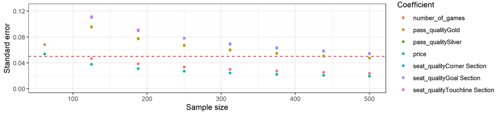

## Changes to Final Survey

Based on feedback from our classmates and our own test runs, we noticed that the consent checkbox did not screen out respondents who did not check the box for being over 18 and having read and understood the consent guidelines. We updated the checkbox to be a compulsory question that has to be marked true. We also added information about the pass quality next to our conjoint question pages in order to remind respondents of the system in place.

# Final Recommendations and Conclusions

Considering the results from analyzing our survey results, we observed that the most influential factor on the survey taker’s willingness to pay is the pass quality; they would prefer a higher priced Gold pass with access to the Final game in comparison to Silver and Bronze passes which provide access to more number of games but in earlier stages. This means the Final games should have higher prices relative to the earlier stages.

The second most significant factor in WTP was the quality of the seats; we observed that the touchline section was more popular, followed by Goal seats, the Corner section, and finally, the upper deck.

We concluded that to increase the attractiveness of our Bronze package for the customers, we need to offer a higher number of games that can compete with the packages that provide a pass to the Final match. It is also important for the Bronze package to provide higher-quality seats.

## Limitations of our analysis

- Our model utilizes logit and WTP models to analyze the survey data.
- Our analysis does not show fans’ WTP compared to watching specific games of teams they do not support.
- Our analysis assumes that fans are more likely to purchase Bronze quality passes and view group stage games if the price is lowered.

## Limitations of our model

- Our survey does not account for individuals outside of the US.
- Our survey is also limited to those with a disposable income high enough to afford the trip to Qatar.
- Factors such as the cost of hotel, cost of flight tickets, elimination of the supported team early in the tournament, visiting multiple games at any single stage of the tournament, and skipping games are not accounted for.
- Our model of the survey does not account for the cost of travel between the airport, hotel, and stadiums.

# Appendix

## Welcome!

Are you excited for the 2022 FIFA World Cup? We are a travel agency offering packages to travel to Qatar, exclusive hotel deals and tickets to matches at different stages of the tournament. We are offering discounted rates during this period and would like to learn more about our customers’ preferences. Answer a few questions to help us decide how we can offer our best.

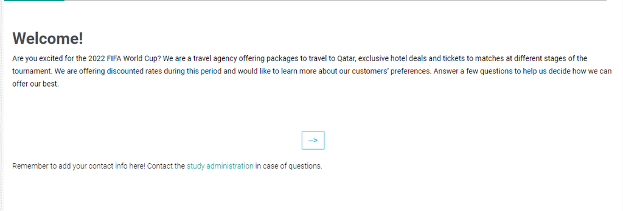

## Consent page

You are invited to participate in an online survey on marketing analytics on a range of 2022 FIFA World Cup Travel Packages. This is a research project being conducted by a group of students at George Washington University. It should take approximately 10 minutes to complete.

Please indicate whether you would like to participate and comply with the following by marking the checkbox labeled “Agree” - You are 18 years of age or older - You have read the above information - You voluntarily wish to participate

Agree →

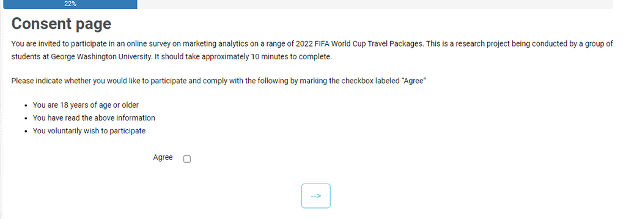

Are you a Soccer/European football fan? → Are you willing to travel for a sporting event any time soon? →

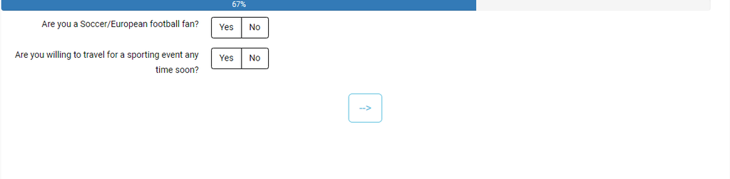

## Great work!

Now that you’ve shared a bit about yourself, we’d like you to consider the following World Cup Ticket packages.

Let’s learn about the attributes for each of the packages.

→

Each of our packages provides you game tickets for the 2022 World Cup. Ticket quality is shown as follows:

## Pass Quality

Packages are broken down into 3 types: Bronze, Silver, and Gold - Bronze: This pass only allows you access to Group Stage games - Silver: This pass allows you to access Group Stage, Round of 16, or Quarter Finals games - Gold: This pass allows you to access games from any stage (Group Stage, Round of 16, Quarter Finals, Semi Finals, and Finals)

## Number of Games Included

Tickets are considered general purpose. That means they can be used for any game that falls within the given pass quality.

## Seat Quality

This describes where in the stadium your seats will be located, from one of 3 sections: - Upper Deck: Seats are in the top sections of the stadium, furthest from the field - Corner Sections: Seats will be in sections near the corners of stadium - Touchline Sections: Seats will be in the sections by the touchline on either side of the field - Goal Sections: Seats will be in the sections behind the goal on either side of the stadium

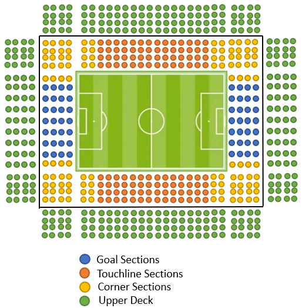

All packages are for only one individual. Tickets may not be used by multiple individuals.

*Please answer these questions to better understand you*

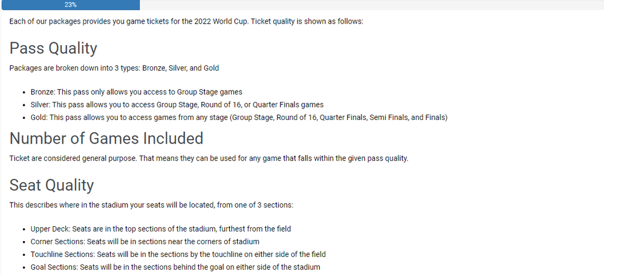

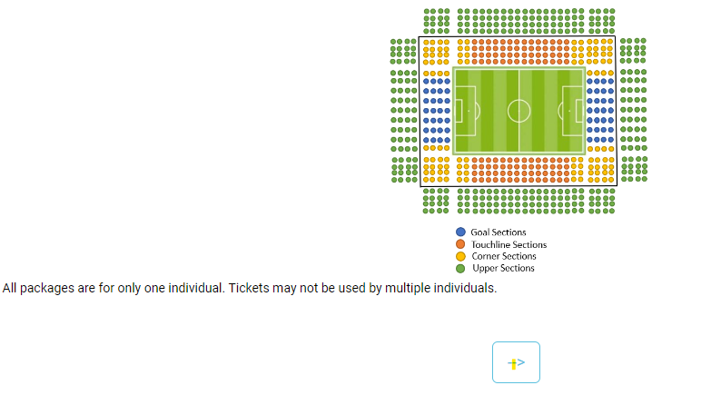

What is your age?

18-30 31-40 41-50 51-60 60+

What is your yearly household income?

<50,000 50,000-80,000 80,000-100,000 100,000-150,000 150,000>

What is your budget for the event?

<$4000 $4000-$6000 $6000-$10,000 $10,000-$15,000 $15,000>

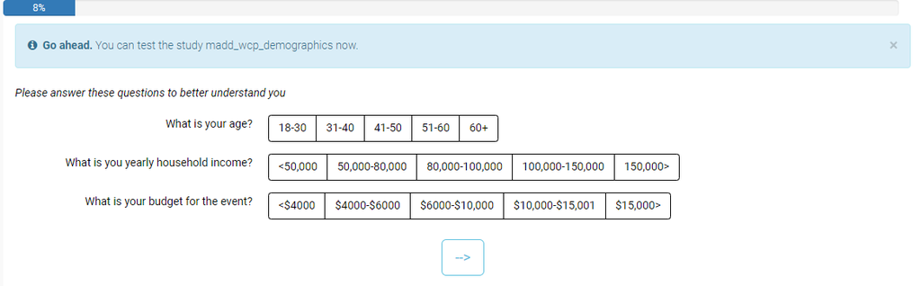

## Team Questions

We would like to learn more about which teams you’d be interested in seeing.

*Drop down of teams*

Would you be interested in seeing any other teams?

Yes No

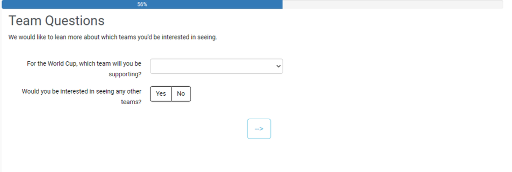

*sample question*

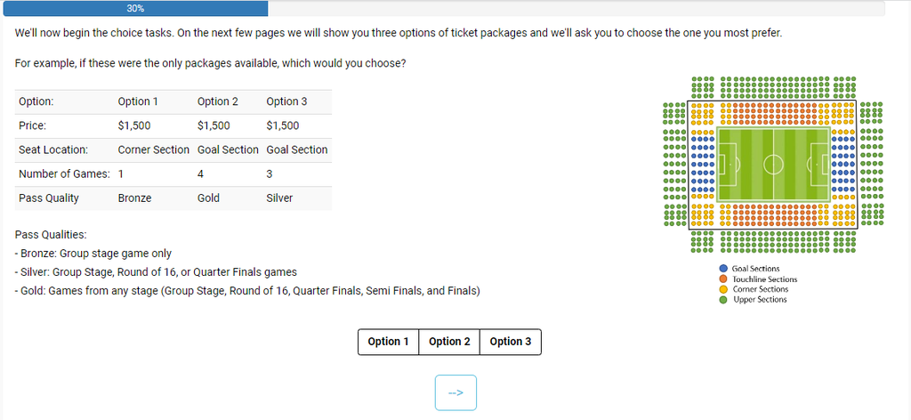

Note:The actual survey consists of 8 questions.